# summary

Andrea & Ottavia

2023-01-24

## Summary

Totale di 80 soggetti. Sono stati tolti 20 perché mancava il consenso ($n = 2$), perché preview 4 o perché sono state fatte il 13 dicembre 14

Dati completi 35

Tenendo uno sbarramento al 70%, si tengono 41 soggetti.

```
##
##  1
## 41
```

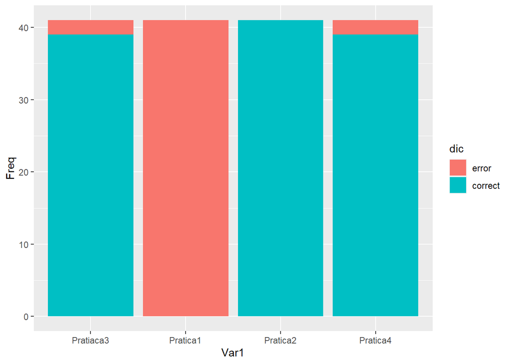

Dettaglio sul distrattore

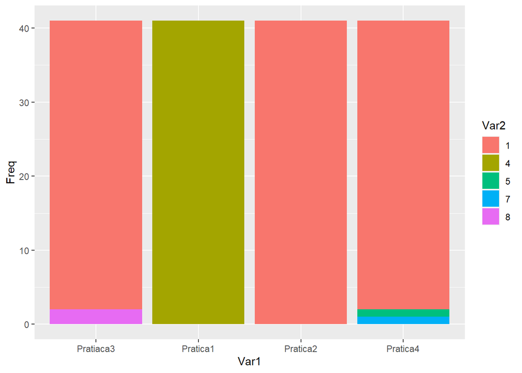

## SetA

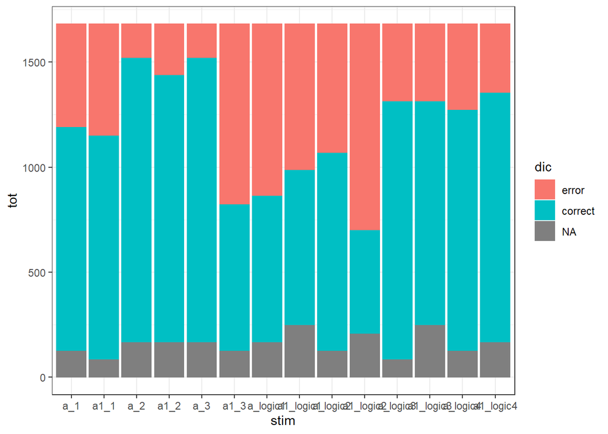

# Accordo

Ho considerato diversi tipi di accordo:

1. tipo 1, accordo grezzo: semplicemente se le risposte sono uguali, NA esclusi
2. tipo 2, accordo sugli NA uguali: risposte uguali e considerando gli NA solo quando sono NA su entrambi gli item, viceversa sono NA
3. tipo 3, accordo sugli NA: risposte uguali alle coppie di item e considerando gli NA nel modo seguente:
   - NA su entrambe: accordo
   - NA su una e risposta errata sull’altra: accordo
   - NA su una e risposta corretta sull’altra: disaccordo

Ad esclusione del primo accordo, forse conviene ragionare solo sui dati puliti (i.e., solo sui dati interi).

## Set A

### Accordo tipo 1

Questo tipo di accordo è il più “grezzo”, non viene considerata l’informazione da parte degli NA, ma solo delle risposte date

```
##       i1       i2       i3      il1      il2      il3      il4
## 53.65854 75.60976 41.46341 56.09756 58.53659 70.73171 70.73171
```

### Accordo tipo 2

In questo caso considero gli NA **SOLO** quando sono NA su entrambe le risposte.

```
##       i1       i2       i3      il1      il2      il3      il4
## 58.53659 82.92683 48.78049 65.85366 65.85366 75.60976 75.60976
```

### Accordo tipo 3

Considero accordo:

- risposte uguali su entrambi gli item (anche entrambi NA)
- NA su una e risposta errata sulla seconda

```
##       i1       i2       i3      il1      il2      il3      il4
## 60.97561 85.36585 51.21951 68.29268 68.29268 80.48780 82.92683
```